# Notebook 02: Flow Data Preprocess

# Goal

In this notebook, I used the code to preprocess each raw fcs file. The preprocess includes compensation and transformation. I would briefly describe the process of preprocessing the data and visualize the data before and after preprocssing via ggplot. Furthermore, I would compare the preprocessing with and without parallel computing. Note that the data was preprocessed via functional programming in R.

# Setup environment

import needed library

```r
library(tidyverse)
library(RColorBrewer)
library(flowCore)   # library for processing flow dataset
library(ggcyto)     # library for visualizing flow dataset
library(parallel)   # library for parallel processing
library(rbenchmark) # library for comparing functions' processing time
```

setup required directory and file names

```r
datadir <- "/data/Flow_HIV"
fclist <- dir(datadir)
fclist <- fclist[grepl("fcs", fclist)]
```

# Introduction of Preprocess FCS Files

Before analysis, a raw fcs file should be properly compensated and transformed. The compensation is preformed to deal with the overlap of emission fluorescence of different flurochrome. The goal of the transformation is to rescale values of measured by fluroescence detectors since the distributions of measurements in flow cytometry is heavily-skewed.

### Compensation

The emission wavelength of different fluorochrome usually overlap to each other. That is, multiple fluorescence spectra may be detected by one flurochrome. Since we need to get the values of each flurorochrome, the spectral overlap should be corrected. The process of compensation is performed as follow:

- get the raw data matrix $X$
- get the spill matrix $M$
- compensation $X \times M^{-1}$

Reference - [Fluorescence compensation in flow cytometry](http://www.abcam.com/protocols/fluorescence-compensation-in-flow-cytometry) - [How To Compensate A 4-Color Flow Cytometry Experiment Correctly](https://expertcytometry.com/how-to-compensate-a-4-color-flow-cytometry-experiment-correctly/)

### Transformation

Due to the heavily-skewed flow cytometry measurements, transformation of flow cytometry measurements is performed before analysis. Different transformation methods have been proposed. Here I listed some some of them.:

- Biexponential Transformation
- Box-Cox Transformation
- Arcsinh Transformation
- Linear-to-Log Transformation

Here I used the arcsinh transformation.

# Preprocess FCS File — Compensation and Transformation

Here I will use the subset of HIV flow cytometry data to demonstrate how compensation and transformation is performed.

```r
# load the subset of data, which contains 10 dataset
load(file.path(datadir, "FlowHIV_Raw_subset10.RData"))
```

print out the markers (Note: ‘A’ represents the area under curve and H is the maximum height)

```r
colnames(fs_sub)
```

```
 [1] "FSC-A"  "FSC-H"  "SSC-A"  "B515-A" "R780-A" "R710-A" "R660-A" "V800-A" "V655-A"
[10] "V585-A" "V450-A" "G780-A" "G710-A" "G660-A" "G610-A" "G560-A"
```

Compensation & Transformation

```r
fdat_raw   <- fs_sub[[1]]
fdat_trans <- preprocess_flowdata(fdat_raw, colnames(fs_sub)[4:16])
```

### Observe the data before and after preprocessing using markers CD3 and CD8.

- R780-A — CD3
- V800-A — CD8

Below is the visualization before preprocessing. Notice that the data points are squeezed in the left below corner.

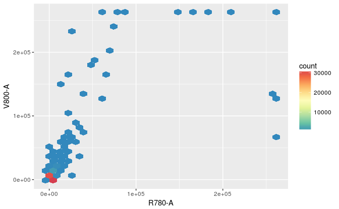

```r
# Before preprocessing
tmp <- fdat_raw[, c("R780-A", "V800-A")]
color_pal <- colorRampPalette(rev(brewer.pal(9, "Spectral")))
gp  <- tmp %>%
    exprs %>%
    as.tibble %>%
    ggplot(aes(x = `R780-A`, y = `V800-A`)) +
    geom_hex() +
    scale_fill_gradientn(colours = color_pal(50))
print(gp)
```

Below is the plot after processing. Notice that it is normal to observe some data points where markers have measurements smaller than zero. Most of the cells (47951/65016 > 70%) are at the first quadrant.

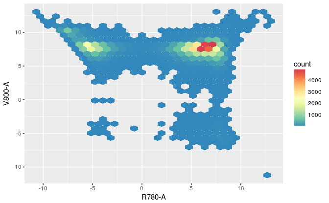

```r
# After processing
tmp <- fdat_trans[, c("R780-A", "V800-A")]
color_pal <- colorRampPalette(rev(brewer.pal(9, "Spectral")))
gp  <- tmp %>%
    exprs %>%
    as.tibble %>%
    ggplot(aes(x = `R780-A`, y = `V800-A`)) +
    geom_hex() +
    scale_fill_gradientn(colours = color_pal(50))
print(gp)
```

### Compare the Preprocessing with and without parallel computing

```r
# Since R is a functional programming language, the function can be decorated and passed as argument
func <- function(file_name){read_preprocess_flowdata(file_name, colnames(fs_sub)[4:16])}
# measure and compare the execution time
dat_timer_results <- benchmark(
    lapply(  X = fclist[1:5], FUN = func),
    mclapply(X = fclist[1:5], FUN = func, mc.cores=detectCores()-1),
    replications = 5,
    order = "relative"
)
dat_timer_results[, -1]
```

|  | replications | elapsed | relative | user.self | sys.self | user.child | sys.child |
| --- | --- | --- | --- | --- | --- | --- | --- |
| 2 | 5 | 10.176 | 1.00 | 0.225 | 1.402 | 14.202 | 6.146 |
| 1 | 5 | 13.022 | 1.28 | 12.215 | 0.804 | 0.000 | 0.000 |

# Preprocess all the files

**Caveat**  
This section requires much more time than other section. Choose one code chunck to preprocess all the fcs files with or without parallel computing. Note that when I executed the code, errors may sometimes occurs randomly.

**Preprocess data without parallel computing**

```r
func <- function(file_name){read_preprocess_flowdata(file_name, colnames(fs_sub)[4:16])}

fs_trans <- lapply(X = fclist, FUN = func)
fs_trans <- flowSet(fs_trans)
```

**Preprocess data with parallel computing**

```r
func <- function(file_name){read_preprocess_flowdata(file_name, colnames(fs_sub)[4:16])}

fs_trans <- mclapply(X = fclist, FUN = func, mc.cores=detectCores()-1)
fs_trans <- flowSet(fs_trans)
```

print out the results

```r
fs_trans
```

store the results

```r
save(fs_trans, file=file.path(datadir, "FlowHIV_Preprocessed.RData"))
```

# Subset for example

preprocess 10 samples for further exploratory data analysis

```r
fs_trans_subset10 <- lapply(X = fclist[1:10], FUN = read_preprocess_flowdata)
names(fs_trans_subset10) <- fclist[1:10]
fs_trans_subset10 <- flowSet(fs_trans_subset10)
fs_trans_subset10
```

store the results

```r
save(fs_trans_subset10, file=file.path(datadir, "FlowHIV_Preprocessed_subset10.RData"))
```

preprocess 100 samples for further exploratory data analysis

```r
fs_trans_subset100 <- lapply(X = fclist[1:100], FUN = read_preprocess_flowdata)
names(fs_trans_subset100) <- fclist[1:100]
fs_trans_subset100 <- flowSet(fs_trans_subset100)
fs_trans_subset100
```

store the results

```r
save(fs_trans_subset100, file=file.path(datadir, "FlowHIV_Preprocessed_subset100.RData"))
```

# Appendix: the markers and their description

| NA | NA | NA | KI67 |
| --- | --- | --- | --- |
| FSC-A | FSC-H | SSC-A | B515-A |
| CD3 | CD28 | CD45RO | CD8 |
| R780-A | R710-A | R660-A | V800-A |
| CD4 | CD57 | VIVID / CD14 | CCR5 |
| V655-A | V585-A | V450-A | G780-A |
| CD19 | CD27 | CCR7 | CD127 |
| G710-A | G660-A | G610-A | G560-A |

```r
fdat <- fs_sub[[1]]
tmp1 <- fdat@parameters@data$name
tmp2 <- fdat@parameters@data$desc
len  <- length(tmp1)
col_name = c(
    tmp1[1:3],
    paste(tmp1[4:len], tmp2[4:len]))
names(col_name) <- NULL
print(col_name)
```

```
 [1] "FSC-A"               "FSC-H"               "SSC-A"               "B515-A KI67"
 [5] "R780-A CD3"          "R710-A CD28"         "R660-A CD45RO"       "V800-A CD8"
 [9] "V655-A CD4"          "V585-A CD57"         "V450-A VIVID / CD14" "G780-A CCR5"
[13] "G710-A CD19"         "G660-A CD27"         "G610-A CCR7"         "G560-A CD127"
```